# Setting up Data

April Peterson

# Mouse Data MLH1

58 old mice (> 25 weeks) were dissected, some of the RIKEN musc strains measures only have old mouse observations.

21 juvinile mice were dissected, mostly only for DMC1 counts. Few had good MLH1 cells so they were removed from the main MLH1 DF.

All images were manually quantified after the file name was anonimized. The original (full) dataset contains the quantification batches with the following number of images. Each batch csv file was merged into Anon.csv by hand.

Number of Images across all the anonimized Batches

| BatchNum | main |
| --- | --- |
| Batch0 | 778 |
| Batch1 | 103 |
| batch10 | 246 |
| Batch11 | 323 |
| batch12 | 95 |
| Batch13 | 185 |
| Batch14 | 337 |
| Batch15 | 255 |
| Batch16 | 239 |
| Batch17 | 69 |
| Batch18 | 256 |
| Batch2 | 155 |
| Batch3 | 175 |
| Batch4 | 165 |
| Batch5 | 93 |
| Batch6 | 177 |
| Batch7 | 197 |
| batch8 | 268 |
| Batch9 | 236 |

# Quality Cleaning steps

The original dataset was cleaned up in the following ways before analysis. Settting up main data file with explanation and examination of data. Make the raw original DF and main working DF with bad cells exlcuede. The original dataset had a number of duplicated file names. These were removed and can be used to quantify repeatability or repair. Using the distinct() function for the MLH1_data, the first duplicated filename is kept and the second removed.

Take out mice from the exclude list based on the output from Mouse level quality plots.

1. The quality of MLH1 counts for individual mice is / was assessed in the MouseLevelPlots Rmd (can I link this file?). A list, mice.to.exclude was made.
2. The list of excluded mice is applied in the MLH1.setup.data script, to remove these mice from the main dataset/dataframe. This script saves .RData file of the dataset which is loaded into Rmd files for analysis

Mouse specific plots of CO count and quality were examined for general quality from single mice. Mice which produced few cells of low quality were excluded to the ‘HQ’ (high quality) dataset. (The full dataset was used to look at some patterns)

## MLH1 mouse level tables

Made up the main mouse level table:

- (Q1-Q4)
- no juvi mice

Subset DFs from here of other analysis.

### DataFrame for Mixed Models

Set up the dataframes in results or MS.

Below I format the DF’s for the models;

1. HetC models: mouse averages, only strains with both sexes, no juvi males, only M.musculus.

update the dissection document (that makes the meta.data DF)

### Number of mice per category

number of mice are in the main DF (discribe the results for missing mice)

Number of cells per mouse, (were any mice excluded for low numbers of cells?) (were all cells pooled?)

## Mouse Ages

Testes were collected from mice at various ages. For some poor breeding mice, I couldn’t collect males at younger ages.

Is there a detectable age effect?

# DMC1

# BivData

for these full curated, add all the labels and save them as excel files in the BivData setup file.

full curated, reduced datasets

Are the strain levels plots needed?

Curated_BivData will be the master DF with most observations. DFs for mixed models and tests need to subsetted from this one.

## Cell Level Table BivData

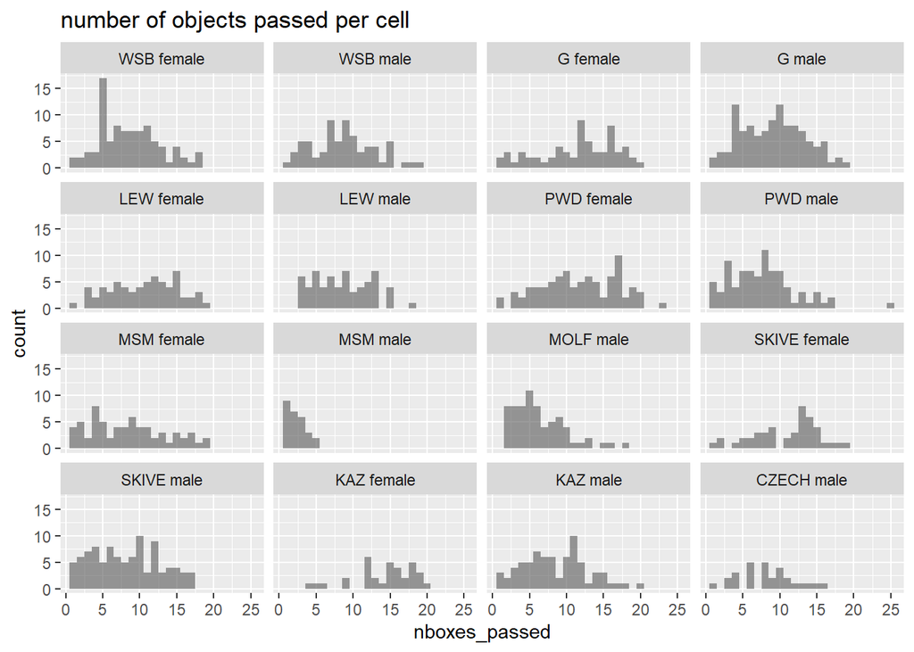

make histogram of the pass rate per cell.

3 cells have manual measures and BivData measures. test error, need to match them up. There are 145 cells from the BivData set which are close to whole cells.  
8jun15_23apr15_PWD_f2_sp1_20_rev, 29nov16_13nov16_MSM_m2_sp1_13_rev, 27oct16_31aug16_MSM_m1_sp1_9_rev

## Reduced Bivalent Dataset (Long and Short)

I want to make a dataset of ‘longest’ and ‘shortest’ bins of bivalents (1st and 4th quartille) from cells with at least 16 segmented bivalents from a single cell.

## Mouse Level Single BivData Table

Mouse level tables are the main meat of the models. There will be several for use in different models. Format these tables for run the mixed models (unordered factors, ect).

analysis using the mouse level table – to justify that using mouse averages is a good idea.

## BivData Melt Position Table

The BivData MELT DF is primarily for the nrmF1.pos plots/analysis. It is a Melted DF for raw and normalized foci positions from the Curated_BivData.

# Total SC

The Total_SC excel file is made from total_SC.rmd, it removes ‘X’ cells and unclear quality scores.

# Saving Data file

Now that the dataframes have been process and formated, they will be saved as RData. the main files are: 1. MLH1_data and original_DF 2. AP_mouse_table and AP_mouse_table_w.Ages 3. meta.data